# Exploratory analysis and visualization

Hildah Njoroge

2023-07-17

### Load necessary packages

```r
library(DESeq2)
```

```r
library(pheatmap)
library(ggplot2)
library(ggrepel)
library(RColorBrewer)
library(limma)
```

### Load data

Load the data saved as a DDS object from the HTG and the HTSeq pipelines ### 1. zero and low expression values filtered from the HTSeq pipleline

```r
load("C:/hne_files/MSc_Bioinf/MScProject-main_C/MScProject-main_10.06.23/scripts/DEG_analysis/Gene_counts/hisat2_htseq_pipeline/htseq_dds_filtering.Rdata")
ddsHTSeq
```

```
## class: DESeqDataSet
## dim: 40879 64
## metadata(1): version
## assays(1): counts
## rownames(40879): 0610005C13Rik 0610006L08Rik ... n-TYgta9 n-Tcgca44
## rowData names(0):
## colnames(64): sample_25_counts.txt sample_26_counts.txt ...
##   sample_54_counts.txt sample_59_counts.txt
## colData names(1): condition
```

```r
dds_cpm_filtered_HTSeq
```

```
## class: DESeqDataSet
## dim: 1626 64
## metadata(1): version
## assays(1): counts
## rownames(1626): A2m Abca1 ... Zfp13 Zic2
## rowData names(0):
## colnames(64): sample_25_counts.txt sample_26_counts.txt ...
##   sample_54_counts.txt sample_59_counts.txt
## colData names(3): sampleName fileName condition
```

```r
dds_rowSums_greaterthan_10_HTSeq
```

```
## class: DESeqDataSet
## dim: 1677 64
## metadata(1): version
## assays(1): counts
## rownames(1677): 4930596D02Rik A2m ... Zfp13 Zic2
## rowData names(0):
## colnames(64): sample_25_counts.txt sample_26_counts.txt ...
##   sample_54_counts.txt sample_59_counts.txt
## colData names(1): condition
```

### 2. zero and low expression values filtered from the HTG pipleline

```r
load("C:/hne_files/MSc_Bioinf/MScProject-main_C/MScProject-main_10.06.23/scripts/DEG_analysis/Gene_counts/htg_pipeline/htg_dds_filtering.Rdata")
ddsHTG
```

```
## class: DESeqDataSet
## dim: 1659 64
## metadata(1): version
## assays(1): counts
## rownames(1659): A2m Abca1 ... Zfp13 Zic2
## rowData names(0):
## colnames(64): sample_25 sample_26 ... sample_54 sample_59
## colData names(4): condition1 condition2 condition3 condition4
```

```r
dds_cpm_filtered_HTG
```

```
## class: DESeqDataSet
## dim: 1653 64
## metadata(1): version
## assays(1): counts
## rownames(1653): A2m Abca1 ... Zfp13 Zic2
## rowData names(0):
## colnames(64): sample_25 sample_26 ... sample_54 sample_59
## colData names(4): condition1 condition2 condition3 condition4
```

```r
dds_rowSums_greaterthan_10_HTG
```

```
## class: DESeqDataSet
## dim: 1659 64
## metadata(1): version
## assays(1): counts
## rownames(1659): A2m Abca1 ... Zfp13 Zic2
## rowData names(0):
## colnames(64): sample_25 sample_26 ... sample_54 sample_59
## colData names(4): condition1 condition2 condition3 condition4
```

## Most statistical methods for EDA of high dimensionla data work best of data that is homoskedastic

This poses a challenge with RNA-Seq raw coutn data that is heteroskedastic, i.e., varaince increases (grows) with mmean value To take care of this, DESEq2 incorporates two methods of data transformation, *rlog - regularised logarithm transformation* and *VST, variance stabilising transformation*. Using ordinary log transformation of normalised data or size-factor normalised data for statistical methods for high dimensional data such as clustering or PCA would not give correct results

### Normalise –> 1. vst for HTG

```r
dds <- ddsHTG
normCounts_vst <- vst(dds, blind = TRUE)
assay(normCounts_vst)[1:5, 1:5] ## counts are not whole numbers as they are fractions of gene counts/median of ratios(size factor) --!! VST does not take into account differences in size factors. This may introduce undesired artifacts for size factors greater than 4
```

```
##        sample_25 sample_26 sample_28 sample_39  sample_1
## A2m     8.256015  7.922926  7.975125  7.922345  8.074741
## Abca1  10.745837 10.700817 10.520522 10.279638 10.705761
## Abcb10  9.420380  9.747123 10.147243  9.834018  9.863481
## Abcb1a  9.226159  9.872288  9.419393 11.284325 10.169721
## Abcb5   7.448942  7.472800  8.211568  7.962593  7.750825
```

### Distribution

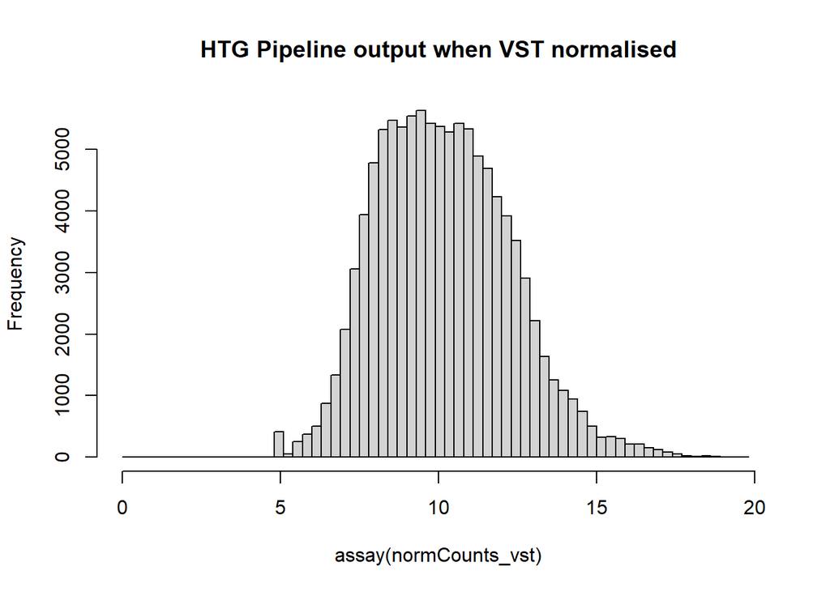

```r
hist(assay(normCounts_vst), main = "HTG Pipeline output when VST normalised",xlim = c(0,20), breaks = seq(0, 20, by = 0.3))
```

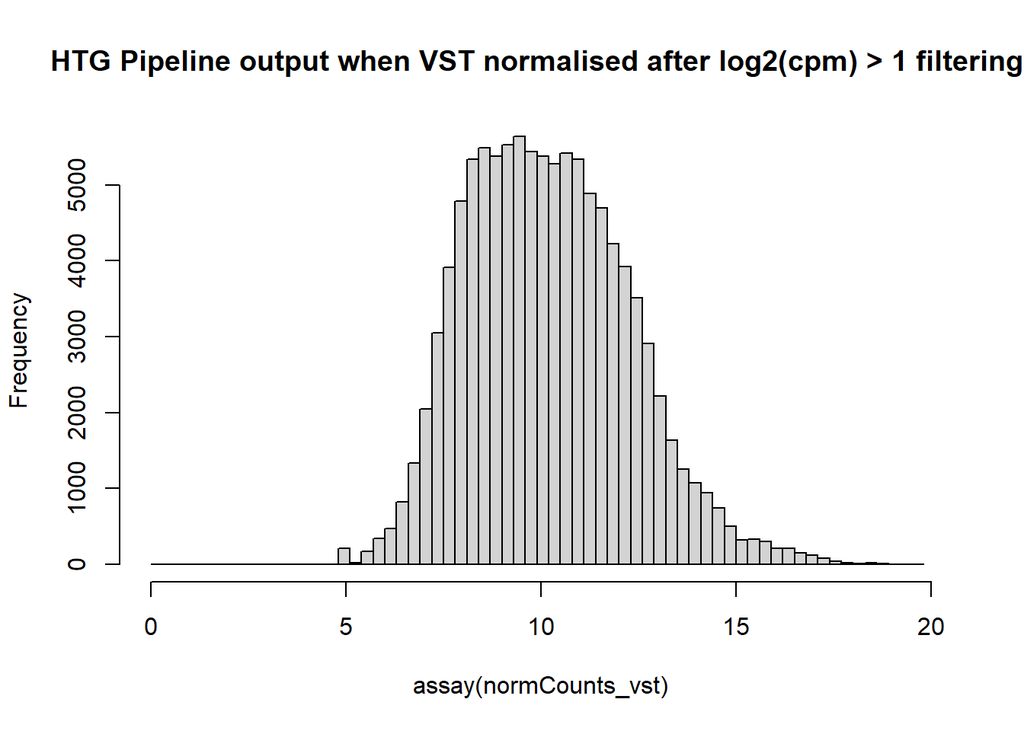

```r
normCounts_vst <- vst(dds_cpm_filtered_HTG, blind = TRUE)
hist(assay(normCounts_vst), main = "HTG Pipeline output when VST normalised after log2(cpm) > 1 filtering ", xlim = c(0,20), breaks = seq(0, 20, by = 0.3))
```

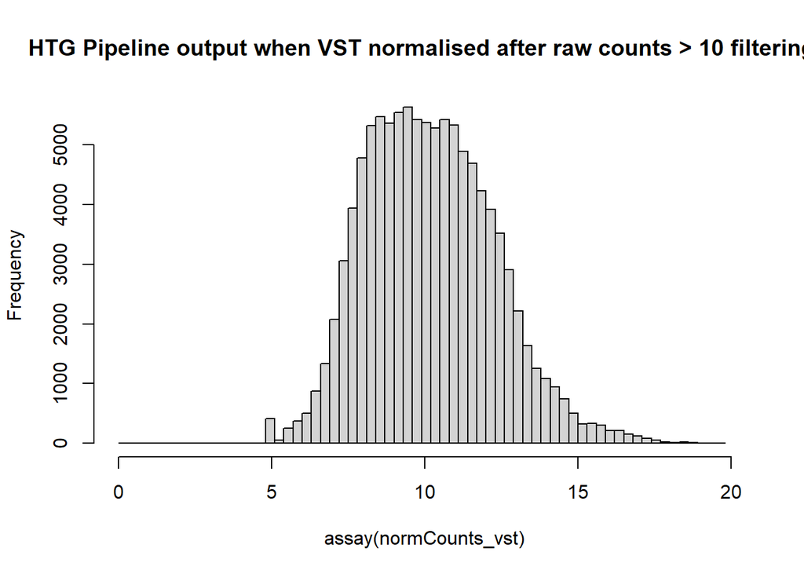

```r
normCounts_vst <- vst(dds_rowSums_greaterthan_10_HTG, blind = TRUE)
hist(assay(normCounts_vst), main = "HTG Pipeline output when VST normalised after raw counts > 10 filtering ", xlim = c(0,20),  breaks = seq(0, 20, by = 0.3))
```

```r
# par( mfrow = c( 2, 2 ) )
#
# #Distribution
# hist(assay(normCounts_vst), main = "HTG Pipeline output when VST normalised",xlim = c(0,20),  breaks = seq(0, 20, by = 0.2))
#
# hist(assay(normCounts_vst), main = "HTG Pipeline output when VST \
# normalised after log2(cpm) > 1 filtering ", xlim = c(0,20), breaks = seq(0, 20, by = 0.2))
#
# hist(assay(normCounts_vst), main = "HTG Pipeline output when VST \
# normalised after raw counts > 10 filtering ", xlim = c(0,20), breaks = seq(0, 20, by = 0.2))
```

We specify blind=FALSE, which means that differences across donors and treatment should not add to the variance-mean profile of the experiment. However, the experimental design is not used directly in the transformation, only in estimating the global amount of variability in the counts. For a fully unsupervised transformation, one can set blind=TRUE (which is the default)

```r
dds <- ddsHTG
rld <- rlog(dds, blind=FALSE); #head(assay(rld), 3)
```

```
## rlog() may take a long time with 50 or more samples,
## vst() is a much faster transformation
```

```r
assay(rld)[1:5,1:5]
```

```
##        sample_25 sample_26 sample_28 sample_39  sample_1
## A2m     7.684627  7.416586  7.458440  7.416348  7.538399
## Abca1  10.567094 10.529760 10.380985 10.182524 10.533737
## Abcb10  9.380866  9.649906  9.978406  9.721303  9.745478
## Abcb1a  9.650757 10.185948  9.813928 11.350888 10.431288
## Abcb5   7.012245  7.032536  7.621173  7.425153  7.256112
```

To show the effect of the transformation, in the figure below is a plot of the first sample against the second, first simply using the log2 function (after adding 1, to avoid taking the log of zero), and then using the rlog-transformed values. For the log2 approach, we need to first estimate size factors to account for sequencing depth, and then specify normalized=TRUE. Sequencing depth correction is done automatically for the rlog method (and for varianceStabilizingTransformation).

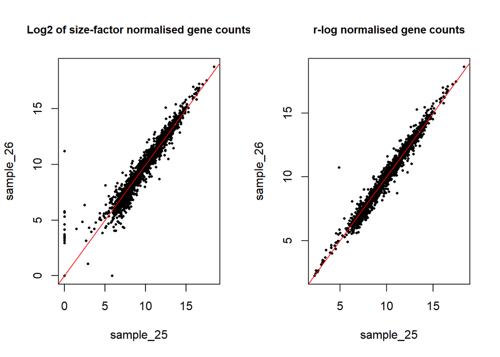

```r
par( mfrow = c( 1, 2 ) )
dds <- estimateSizeFactors(dds)
plot(log2(counts(dds, normalized=TRUE)[,1:2] + 1), pch=16, cex=0.5, cex.main=0.9, main="Log2 of size-factor normalised gene counts")
abline(a = 0, b = 1, col = "red")
plot(assay(rld)[,1:2], pch=16, cex=0.5,cex.main=0.9, main=("r-log normalised gene counts"))
# plot(assay(normCounts_vst[,1:2]),pch=16, cex=0.5, main="VST normalised gene counts")
abline(a = 0, b = 1, col = "red")
```

```r
# par(mfrow = c(1, 2))
#
# plot(1:10, main = "Plot 1")
# plot(11:20, main = "Plot 2")
#
# # Add a title to the entire plot
# main_title <- "Side-by-Side Plots"
# mtext(main_title, outer = TRUE, line = 0.5, cex = 1.5)
```

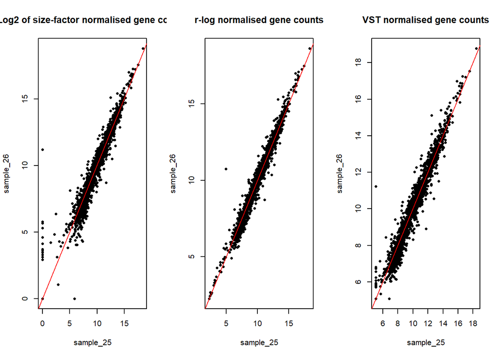

```r
par( mfrow = c( 1, 3 ) )
dds <- estimateSizeFactors(dds)
plot(log2(counts(dds, normalized=TRUE)[,1:2] + 1), pch=16, cex=0.7, main="Log2 of size-factor normalised gene counts")
abline(a = 0, b = 1, col = "red")
plot(assay(rld)[,1:2], pch=16, cex=0.7, main=("r-log normalised gene counts"))
abline(a = 0, b = 1, col = "red")
plot(assay(normCounts_vst[,1:2]),pch=16, cex=0.7, main="VST normalised gene counts")
abline(a = 0, b = 1, col = "red")
```

```r
# Add a title to the entire plot
# main_title <- "Side-by-Side plots of the first sample against\
# the second using different approaches of normalising the gene expression data"
# # mtext(main_title, outer = TRUE, line = 0.5, cex = 1.5)
# mtext(main_title, side = 3, line = 2, cex = 1)
```

#### Distribution of r-log transformed gene counts

```r
normCounts_rlog <- rlog(dds, blind = TRUE)
```

```
## rlog() may take a long time with 50 or more samples,
## vst() is a much faster transformation
```

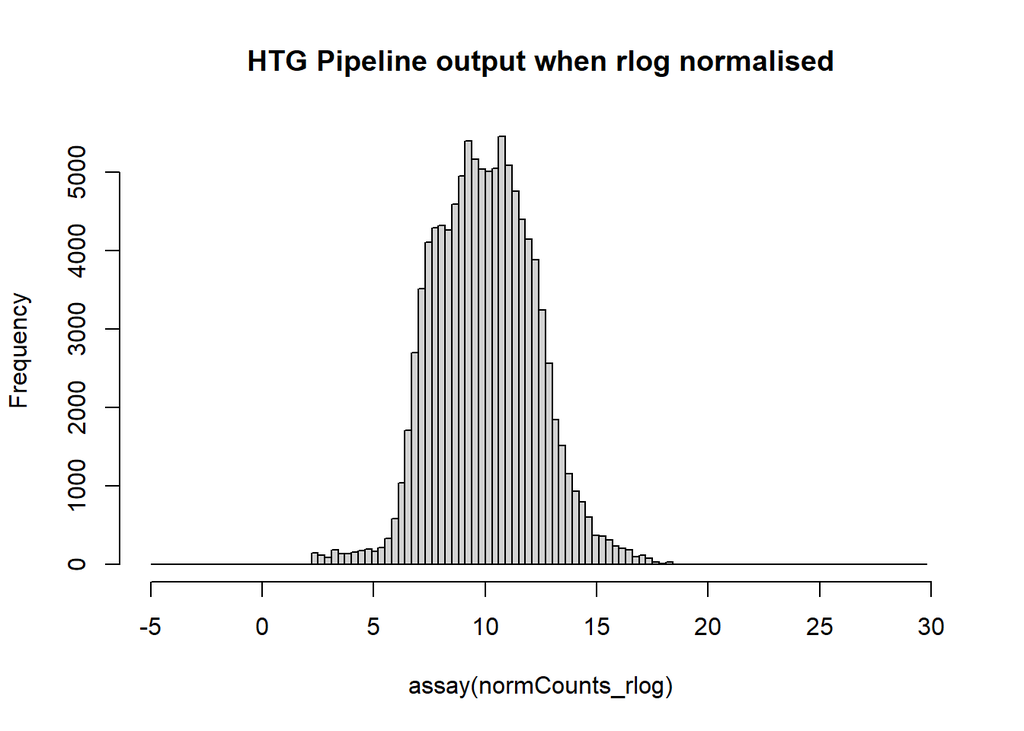

```r
hist(assay(normCounts_rlog), main = "HTG Pipeline output when rlog normalised",xlim = c(-5,30), breaks = seq(-5, 30, by = 0.3))
```

```r
normCounts_rlog <- rlog(dds_cpm_filtered_HTG, blind = TRUE)
```

```
## rlog() may take a long time with 50 or more samples,
## vst() is a much faster transformation
```

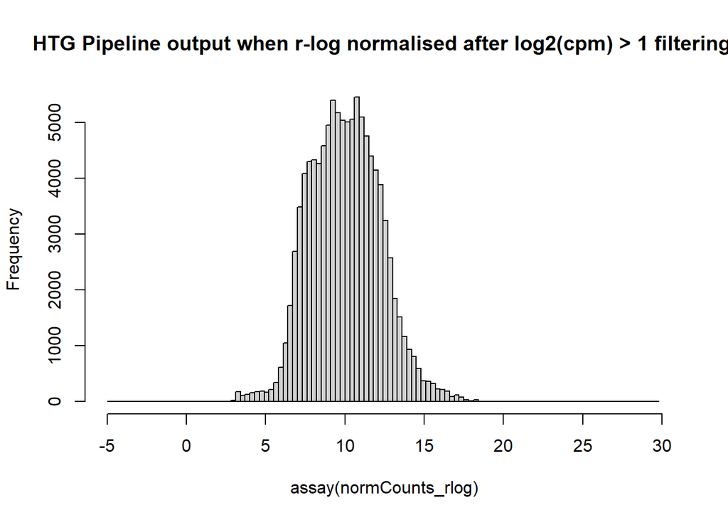

```r
hist(assay(normCounts_rlog), main = "HTG Pipeline output when r-log normalised after log2(cpm) > 1 filtering ",  xlim = c(-5,30), breaks = seq(-5, 30, by = 0.3))
```

```r
normCounts_rlog <- rlog(dds_rowSums_greaterthan_10_HTG, blind = TRUE)
```

```
## rlog() may take a long time with 50 or more samples,
## vst() is a much faster transformation
```

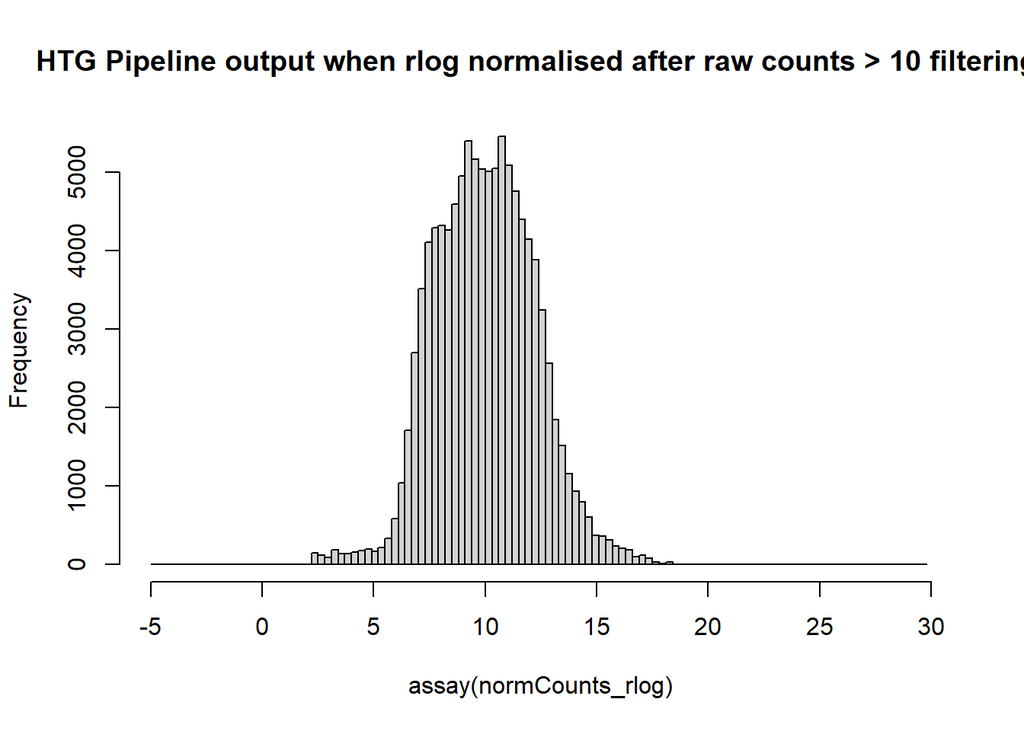

```r
hist(assay(normCounts_rlog), main = "HTG Pipeline output when rlog normalised after raw counts > 10 filtering ", xlim = c(-5,30),  breaks = seq(-5, 30, by = 0.3))
```

```r
# par( mfrow = c( 1, 2 ) )
#
# #Distribution
# hist(assay(rld), main = "HTG Pipeline output when r-log normalised",xlim = c(0,20),  breaks = seq(0, 20, by = 0.2))
#
# hist(assay(rld), main = "HTG Pipeline output when r-log \
# normalised after log2(cpm) > 1 filtering ", xlim = c(0,20), breaks = seq(0, 20, by = 0.2))
# #
# # hist(assay(rld), main = "HTG Pipeline output when r-log \
# # normalised after raw counts > 10 filtering ", xlim = c(0,20), breaks = seq(0, 20, by = 0.2))
```

## Plotting the sample heatmap

#### first, generate the similarity/distance matrix showing the pairwise distances (similarity or dissimilarity between samples).

```r
sampleDist_rlog <- cor(assay(normCounts_rlog), method = "spearman")
sampleDist_rlog[1:6,1:6]
```

```
##           sample_25 sample_26 sample_28 sample_39  sample_1 sample_21
## sample_25 1.0000000 0.9897792 0.9911565 0.9656339 0.9916919 0.9935580
## sample_26 0.9897792 1.0000000 0.9910416 0.9748364 0.9908101 0.9886502
## sample_28 0.9911565 0.9910416 1.0000000 0.9689024 0.9898213 0.9910266
## sample_39 0.9656339 0.9748364 0.9689024 1.0000000 0.9709211 0.9677937
## sample_1  0.9916919 0.9908101 0.9898213 0.9709211 1.0000000 0.9936352
## sample_21 0.9935580 0.9886502 0.9910266 0.9677937 0.9936352 1.0000000
```

```r
sampleDist_rlog <- cor(assay(normCounts_rlog), method = "pearson")
sampleDist_rlog[1:6,1:6]
```

```
##           sample_25 sample_26 sample_28 sample_39  sample_1 sample_21
## sample_25 1.0000000 0.9905021 0.9918313 0.9699826 0.9923730 0.9941466
## sample_26 0.9905021 1.0000000 0.9905911 0.9771646 0.9912111 0.9894777
## sample_28 0.9918313 0.9905911 1.0000000 0.9737317 0.9914728 0.9920537
## sample_39 0.9699826 0.9771646 0.9737317 1.0000000 0.9763316 0.9728274
## sample_1  0.9923730 0.9912111 0.9914728 0.9763316 1.0000000 0.9940660
## sample_21 0.9941466 0.9894777 0.9920537 0.9728274 0.9940660 1.0000000
```

## QS: wby use the Spearman option? IS it because the distribution of normalised count data is not normally distributed? Right sqewed?

```r
sampleDist_vst <- cor(assay(normCounts_vst), method = "spearman")
sampleDist_vst[1:6,1:6]
```

```
##           sample_25 sample_26 sample_28 sample_39  sample_1 sample_21
## sample_25 1.0000000 0.9738611 0.9769753 0.9087254 0.9777302 0.9833004
## sample_26 0.9738611 1.0000000 0.9739499 0.9324703 0.9764312 0.9706340
## sample_28 0.9769753 0.9739499 1.0000000 0.9113943 0.9717516 0.9756691
## sample_39 0.9087254 0.9324703 0.9113943 1.0000000 0.9218927 0.9140165
## sample_1  0.9777302 0.9764312 0.9717516 0.9218927 1.0000000 0.9823824
## sample_21 0.9833004 0.9706340 0.9756691 0.9140165 0.9823824 1.0000000
```

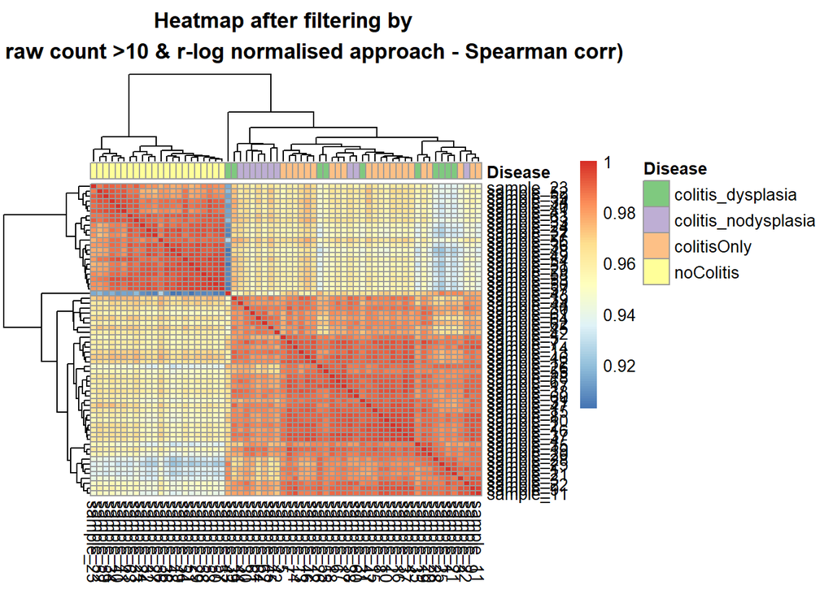

```r
par(mfrow=c(3,1))

sampleDist_rlog <- cor(assay(normCounts_rlog), method = "spearman")

sampleColor <- brewer.pal(4, "Accent")[1:4]
# sampleColor <- cols <- c( "red","orange", "#0080FF","lightgreen")
names(sampleColor) <- levels(coldata$condition2)
pheatmap(sampleDist_rlog,
         clustering_distance_rows = as.dist(1 - sampleDist_rlog),
         clustering_distance_cols = as.dist(1 - sampleDist_rlog),
         annotation_col = data.frame(Disease = coldata$condition2,
                                     row.names = row.names(coldata)),
         annotation_colors = list(Disease = sampleColor),
         main = "Heatmap after filtering by \
         raw count >10 & r-log normalised approach - Spearman corr)")
```

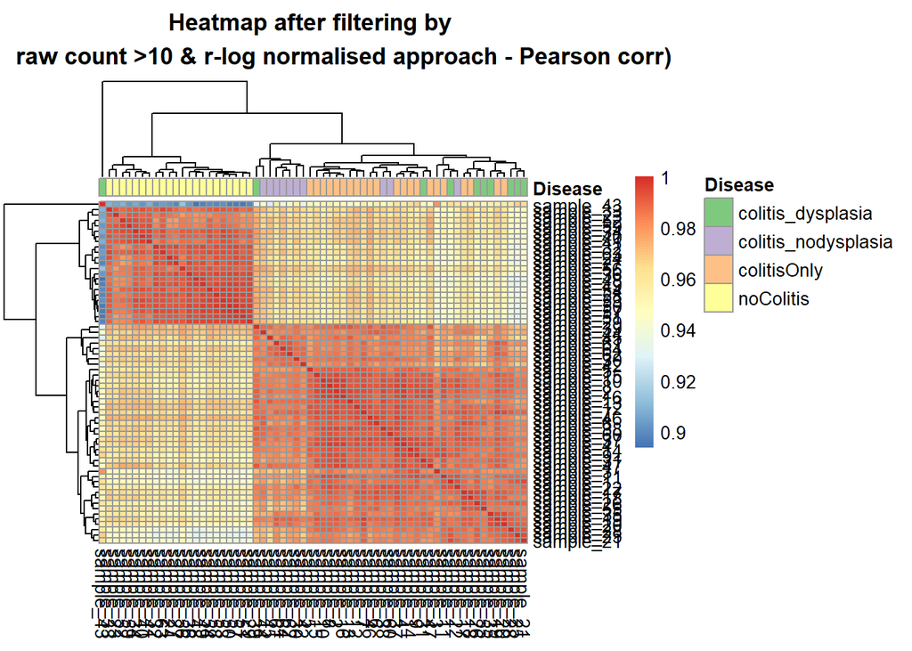

```r
sampleDist_rlog <- cor(assay(normCounts_rlog), method = "pearson")

sampleColor <- brewer.pal(4, "Accent")[1:4]
# sampleColor <- cols <- c( "red","orange", "#0080FF","lightgreen")
names(sampleColor) <- levels(coldata$condition2)
pheatmap(sampleDist_rlog,
         clustering_distance_rows = as.dist(1 - sampleDist_rlog),
         clustering_distance_cols = as.dist(1 - sampleDist_rlog),
         annotation_col = data.frame(Disease = coldata$condition2,
                                     row.names = row.names(coldata)),
         annotation_colors = list(Disease = sampleColor),
         main = "Heatmap after filtering by \
         raw count >10 & r-log normalised approach - Pearson corr)")
```

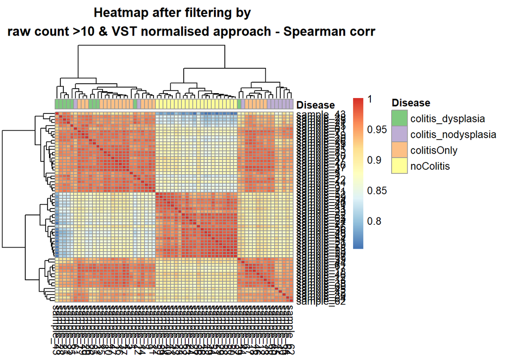

```r
sampleDist_vst <- cor(assay(normCounts_vst), method = "spearman")
pheatmap(sampleDist_vst,
         clustering_distance_rows = as.dist(1 - sampleDist_vst),
         clustering_distance_cols = as.dist(1 - sampleDist_vst),
         annotation_col = data.frame(Disease = coldata$condition2,
                                     row.names = row.names(coldata)),
         annotation_colors = list(Disease = sampleColor),
         main = "Heatmap after filtering by \
         raw count >10 & VST normalised approach - Spearman corr")
```

## this was calculated using the example from the paper *RNA-Seq workflow: Gene-level exploratory analysis and differential expression, by Love et.al*

```r
sampleDist_rlog2 <- dist( t( assay(normCounts_rlog) ) )
sampleDist_rlog2[1:6]
```

```
## [1] 13.42492 12.45444 23.07116 11.68090 10.19654 15.04150
```

```r
sampleDistMatrix <- as.matrix( sampleDist_rlog2 )
sampleDistMatrix[1:6,1:6]
```

```
##           sample_25 sample_26 sample_28 sample_39 sample_1 sample_21
## sample_25   0.00000  13.42492  12.45444  23.07116 11.68090  10.19654
## sample_26  13.42492   0.00000  14.42011  21.32564 13.30419  14.12697
## sample_28  12.45444  14.42011   0.00000  20.64612 12.13658  12.23497
## sample_39  23.07116  21.32564  20.64612   0.00000 20.08936  21.95772
## sample_1   11.68090  13.30419  12.13658  20.08936  0.00000  10.29895
## sample_21  10.19654  14.12697  12.23497  21.95772 10.29895   0.00000
```

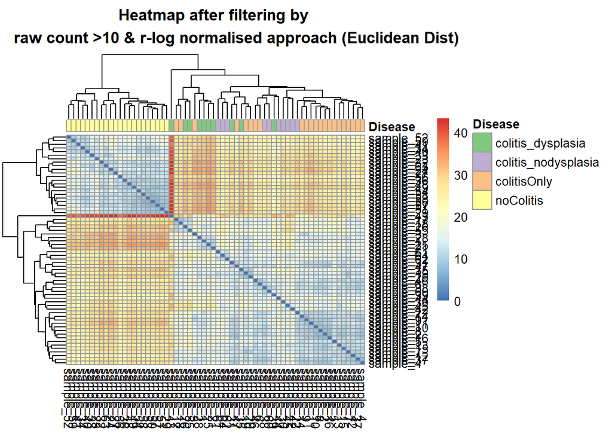

```r
# rownames(sampleDistMatrix) <- paste( rld$dex, rld$cell, sep="-" )
# colnames(sampleDistMatrix) <- NULL
colnames(sampleDistMatrix) <- rownames(coldata)
sampleColor <- brewer.pal(4, "Accent")[1:4]
# sampleColor <- cols <- c( "red","orange", "#0080FF","lightgreen")
names(sampleColor) <- levels(coldata$condition2)
# colors <- colorRampPalette( rev(brewer.pal(9, "Blues")) )(255)
# pheatmap(sampleDistMatrix,
#          clustering_distance_rows=sampleDist_rlog2,
#          clustering_distance_cols=sampleDist_rlog2,
#          col=colors)

pheatmap(sampleDistMatrix,
         clustering_distance_rows=sampleDist_rlog2,
         clustering_distance_cols=sampleDist_rlog2,
         annotation_col = data.frame(Disease = coldata$condition2,
                                     row.names = row.names(coldata)),
         annotation_colors = list(Disease = sampleColor),
         main = "Heatmap after filtering by \
         raw count >10 & r-log normalised approach (Euclidean Dist)")
```